# Упражнение 8

Александрова Александра

12 05 2021

# Задание:

Построить две модели для прогноза на основе дерева решений:

- для непрерывной зависимой переменной;
- для категориальной зависимой переменной.

Данные и переменные указаны в таблице с вариантами. Ядро генератора случайных чисел – номер варианта.

Для каждой модели:

- Указать настроечные параметры метода из своего варианта (например: количество узлов, количество предикторов, скорость обучения).
- Подогнать модель на обучающей выборке (50% наблюдений). Рассчитать MSE на тестовой выборке.
- Перестроить модель с помощью метода, указанного в варианте.
- Сделать прогноз по модели с подобранными в п.3 параметрами на тестовой выборке, оценить его точность и построить график «прогноз-реализация».

# Вариант 2

Модели: бэггинг (количество предикторов). Данные: ‘Boston {MASS}’.

```r
# Название столбцов переменных
names(Boston)
```

```
##  [1] "crim"    "zn"      "indus"   "chas"    "nox"     "rm"      "age"
##  [8] "dis"     "rad"     "tax"     "ptratio" "black"   "lstat"   "medv"
```

```r
# Размерность данных
dim(Boston)
```

```
## [1] 506  14
```

```r
# Ядро генератора случайных чисел
my.seed <- 2
```

# Модель 1 (для непрерывной зависимой переменной medv)

```r
head(Boston)
```

```
##      crim zn indus chas   nox    rm  age    dis rad tax ptratio  black lstat
## 1 0.00632 18  2.31    0 0.538 6.575 65.2 4.0900   1 296    15.3 396.90  4.98
## 2 0.02731  0  7.07    0 0.469 6.421 78.9 4.9671   2 242    17.8 396.90  9.14
## 3 0.02729  0  7.07    0 0.469 7.185 61.1 4.9671   2 242    17.8 392.83  4.03
## 4 0.03237  0  2.18    0 0.458 6.998 45.8 6.0622   3 222    18.7 394.63  2.94
## 5 0.06905  0  2.18    0 0.458 7.147 54.2 6.0622   3 222    18.7 396.90  5.33
## 6 0.02985  0  2.18    0 0.458 6.430 58.7 6.0622   3 222    18.7 394.12  5.21
##   medv
## 1 24.0
## 2 21.6
## 3 34.7
## 4 33.4
## 5 36.2
## 6 28.7
```

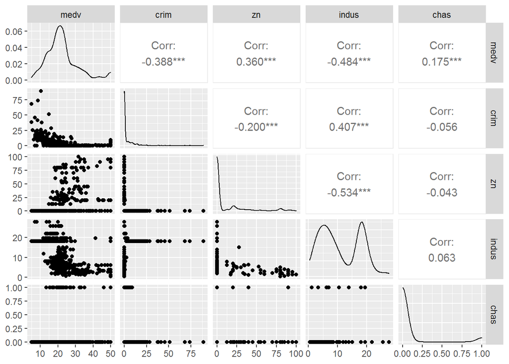

```r
# Матричные графики разброса переменных
p <- ggpairs(Boston[, c(14, 1:4)])
suppressMessages(print(p))
```

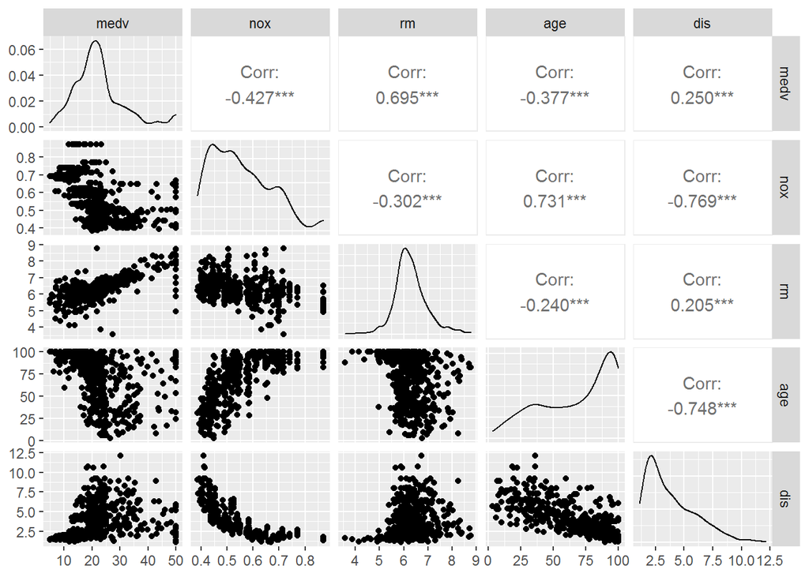

```r
p <- ggpairs(Boston[, c(14, 5:8)])
suppressMessages(print(p))
```

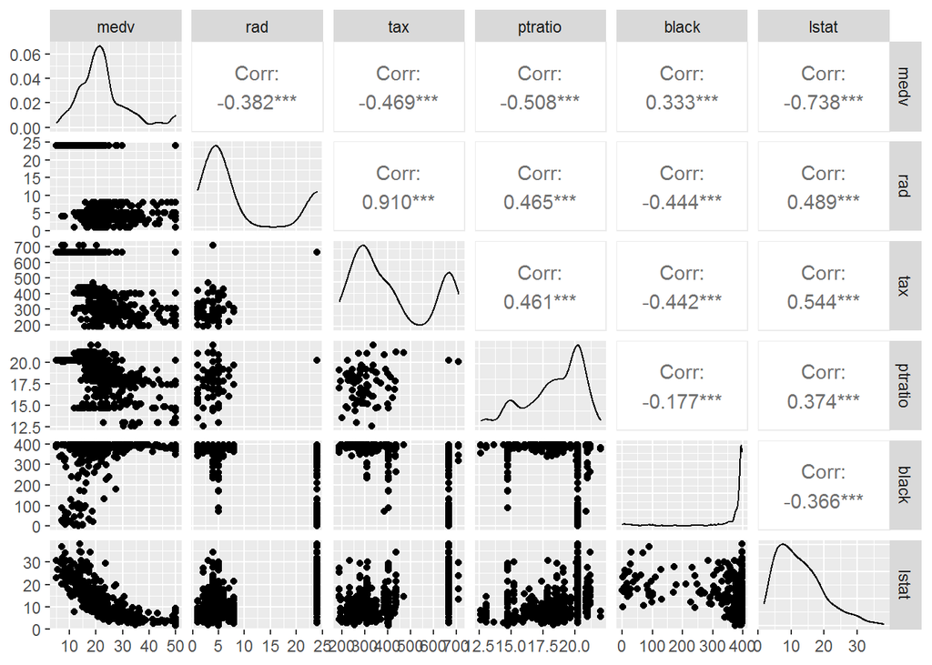

```r
p <- ggpairs(Boston[, c(14, 9:13)])
suppressMessages(print(p))
```

```r
# Обучающая выборка
set.seed(my.seed)
# Обучающая выборка - 50%
train <- sample(1:nrow(Boston), nrow(Boston)/2)
```

Построим дерево регрессии для зависимой переменной medv

```r
# Обучаем модель
tree.boston <- tree(medv ~ ., Boston, subset = train)
summary(tree.boston)
```

```
##
## Regression tree:
## tree(formula = medv ~ ., data = Boston, subset = train)
## Variables actually used in tree construction:
## [1] "rm"      "lstat"   "dis"     "crim"    "ptratio"
## Number of terminal nodes:  9
## Residual mean deviance:  17.36 = 4236 / 244
## Distribution of residuals:
##     Min.  1st Qu.   Median     Mean  3rd Qu.     Max.
## -18.5100  -2.1100  -0.1246   0.0000   1.8950  20.6700
```

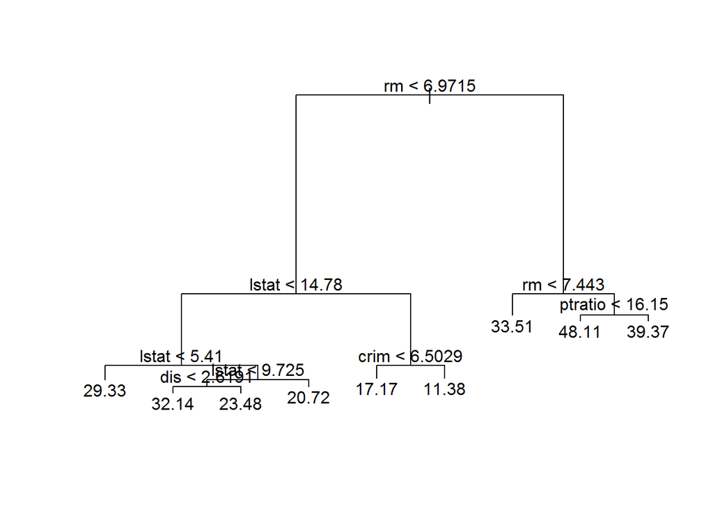

```r
# Визуализация
plot(tree.boston)
text(tree.boston, pretty = 0)
```

```r
tree.boston                    # Посмотреть всё дерево в консоли
```

```
## node), split, n, deviance, yval
##       * denotes terminal node
##
##  1) root 253 21670.00 22.80
##    2) rm < 6.9715 218  8653.00 20.24
##      4) lstat < 14.78 137  3364.00 23.42
##        8) lstat < 5.41 18   677.60 29.33 *
##        9) lstat > 5.41 119  1962.00 22.52
##         18) lstat < 9.725 62  1253.00 24.18
##           36) dis < 2.6191 5   510.80 32.14 *
##           37) dis > 2.6191 57   397.30 23.48 *
##         19) lstat > 9.725 57   355.60 20.72 *
##      5) lstat > 14.78 81  1580.00 14.88
##       10) crim < 6.5029 49   610.60 17.17 *
##       11) crim > 6.5029 32   321.70 11.38 *
##    3) rm > 6.9715 35  2764.00 38.68
##      6) rm < 7.443 19   768.60 33.51 *
##      7) rm > 7.443 16   881.00 44.83
##       14) ptratio < 16.15 10    72.39 48.11 *
##       15) ptratio > 16.15 6   521.90 39.37 *
```

```r
# Прогноз по модели
yhat <- predict(tree.boston, newdata = Boston[-train, ])
boston.test <- Boston[-train, "medv"]

# MSE на тестовой выборке
mse.test <- mean((yhat - boston.test)^2)
names(mse.test)[length(mse.test)] <- 'Boston.regr.tree.all'
mse.test
```

```
## Boston.regr.tree.all
##               19.631
```

```r
# Точность прогноза на тестовой выборке
acc.test <- sum(abs(yhat-boston.test))/sum(boston.test)
names(acc.test)[length(acc.test)] <- 'Boston.regr.tree.all'
acc.test
```

```
## Boston.regr.tree.all
##            0.1387211
```

# Бэггинг (модель 1)

```r
# бэггинг с 13 предикторами
set.seed(my.seed)
bag.boston <- randomForest(medv ~ ., data = Boston, subset = train,
                           mtry = 13, importance = TRUE)

bag.boston
```

```
##
## Call:
##  randomForest(formula = medv ~ ., data = Boston, mtry = 13, importance = TRUE,      subset = train)
##                Type of random forest: regression
##                      Number of trees: 500
## No. of variables tried at each split: 13
##
##           Mean of squared residuals: 15.94194
##                     % Var explained: 81.39
```

```r
# прогноз
yhat.bag = predict(bag.boston, newdata = Boston[-train, ])

# MSE на тестовой
mse.test <- c(mse.test, mean((yhat.bag - boston.test)^2))
names(mse.test)[length(mse.test)] <- 'Boston.bag.model.1.13'
mse.test
```

```
##  Boston.regr.tree.all Boston.bag.model.1.13
##             19.630998              9.859006
```

```r
# Точность прогноза на тестовой выборке
acc.test <- sum(abs(yhat.bag-boston.test))/sum(boston.test)
names(acc.test)[length(acc.test)] <- 'Boston.regr.tree.model.1.13'
acc.test
```

```
## Boston.regr.tree.model.1.13
##                   0.1005583
```

Ошибка на тестовой выборке равна 9.86. Можно изменить число деревьев с помощью аргумента.

```r
# Бэггинг с 13 предикторами и 25 деревьями
bag.boston <- randomForest(medv ~ ., data = Boston, subset = train,
                           mtry = 13, ntree = 25)

# прогноз
yhat.bag <- predict(bag.boston, newdata = Boston[-train, ])

# MSE на тестовой
mse.test <- c(mse.test, mean((yhat.bag - boston.test)^2))
names(mse.test)[length(mse.test)] <- 'Boston.bag.model.1.13.25'
mse.test
```

```
##     Boston.regr.tree.all    Boston.bag.model.1.13 Boston.bag.model.1.13.25
##                19.630998                 9.859006                 9.959973
```

```r
# Точность прогноза на тестовой выборке
acc.test <- c(acc.test, sum(abs(yhat.bag-boston.test))/sum(boston.test))
names(acc.test)[length(acc.test)] <- 'Boston.regr.tree.model.1.13.25'
acc.test
```

```
##    Boston.regr.tree.model.1.13 Boston.regr.tree.model.1.13.25
##                      0.1005583                      0.1021754
```

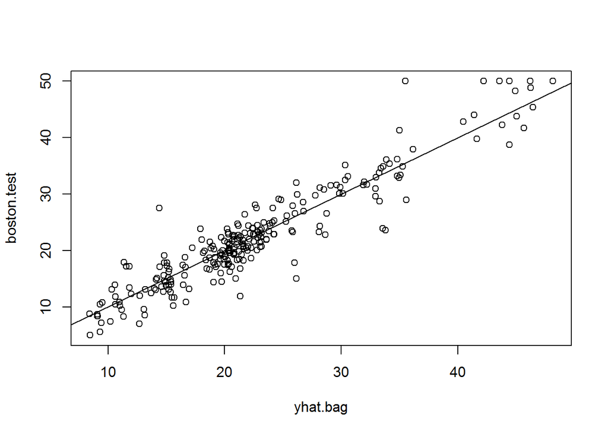

```r
# График прогноз - реализация
plot(yhat.bag, boston.test)
# линия идеального прогноза
abline(0, 1)
```

Судя по полученным результатам наименьшая MSE наблюдается у модели с использованием бэггинга с 13 предикторами. Минимальная MSE на тестовой выборке равна 9.859, точность прогноза составила 0.1.

# Модель 2 (для категориальной зависимой переменной high.medv)

```r
# Новая переменная
high.medv <- ifelse(Boston$medv < 25, '0', '1')
high.medv <- factor(high.medv, labels = c('yes', 'no'))

Boston$high.medv <- high.medv

# Название столбцов переменных
names(Boston)
```

```
##  [1] "crim"      "zn"        "indus"     "chas"      "nox"       "rm"
##  [7] "age"       "dis"       "rad"       "tax"       "ptratio"   "black"
## [13] "lstat"     "medv"      "high.medv"
```

```r
# Размерность данных
dim(Boston)
```

```
## [1] 506  15
```

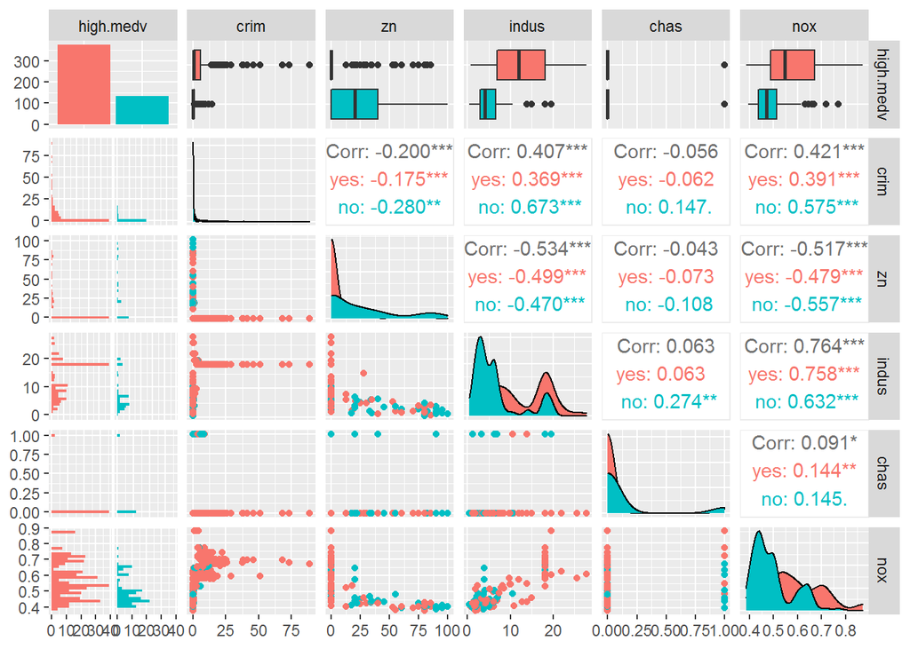

```r
# Матричные графики разброса переменных
p <- ggpairs(Boston[, c(15, 1:5)], aes(color = high.medv))
suppressMessages(print(p))
```

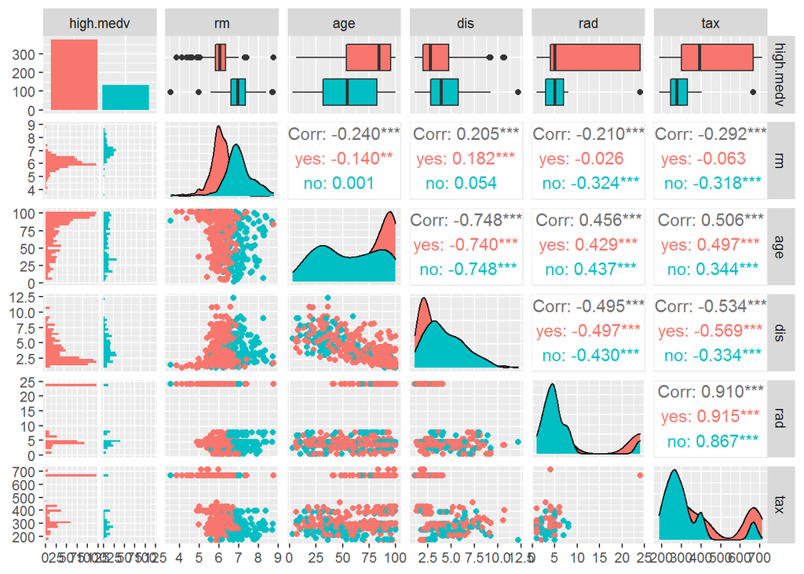

```r
p <- ggpairs(Boston[, c(15, 6:10)], aes(color = high.medv))
suppressMessages(print(p))
```

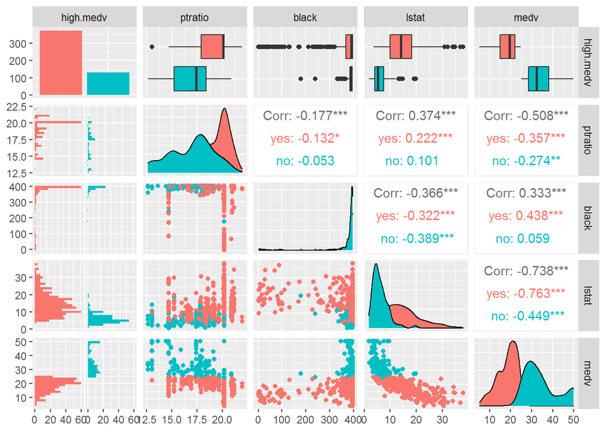

```r
p <- ggpairs(Boston[, c(15, 11:14)], aes(color = high.medv))
suppressMessages(print(p))
```

Судя по графикам, класс 0 превосходит по размеру класс 1 по переменной high.medv приблизительно в 3 раза.

Построим дерево для категориального отклика high.medv, отбросив непрерывный отклик medv.

```r
# Модель бинарного  дерева
tree.boston <- tree(high.medv ~ . -medv, Boston)
summary(tree.boston)
```

```
##
## Classification tree:
## tree(formula = high.medv ~ . - medv, data = Boston)
## Variables actually used in tree construction:
## [1] "rm"    "lstat" "crim"  "tax"   "age"   "indus" "nox"
## Number of terminal nodes:  16
## Residual mean deviance:  0.1975 = 96.77 / 490
## Misclassification error rate: 0.03557 = 18 / 506
```

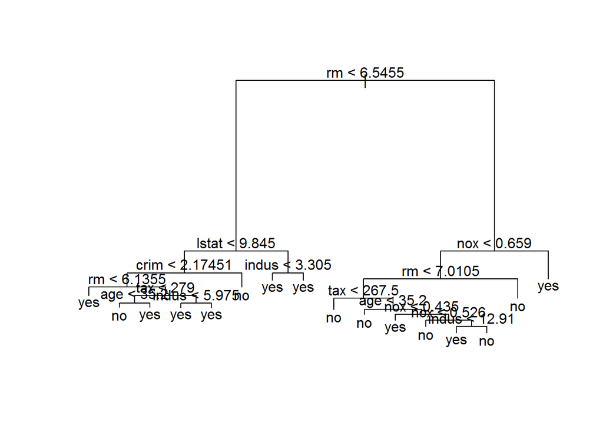

```r
# График результата
plot(tree.boston)                # Ветви
text(tree.boston, pretty = 0)    # Подписи
```

```r
tree.boston                      # Посмотреть всё дерево в консоли
```

```
## node), split, n, deviance, yval, (yprob)
##       * denotes terminal node
##
##   1) root 506 580.900 yes ( 0.739130 0.260870 )
##     2) rm < 6.5455 362 165.900 yes ( 0.939227 0.060773 )
##       4) lstat < 9.845 93  91.390 yes ( 0.806452 0.193548 )
##         8) crim < 2.17451 87  69.810 yes ( 0.862069 0.137931 )
##          16) rm < 6.1355 33   0.000 yes ( 1.000000 0.000000 ) *
##          17) rm > 6.1355 54  57.210 yes ( 0.777778 0.222222 )
##            34) tax < 279 18  24.950 no ( 0.500000 0.500000 )
##              68) age < 35.2 7   5.742 no ( 0.142857 0.857143 ) *
##              69) age > 35.2 11  12.890 yes ( 0.727273 0.272727 ) *
##            35) tax > 279 36  20.650 yes ( 0.916667 0.083333 )
##              70) indus < 5.975 23   0.000 yes ( 1.000000 0.000000 ) *
##              71) indus > 5.975 13  14.050 yes ( 0.769231 0.230769 ) *
##         9) crim > 2.17451 6   0.000 no ( 0.000000 1.000000 ) *
##       5) lstat > 9.845 269  41.610 yes ( 0.985130 0.014870 )
##        10) indus < 3.305 5   6.730 yes ( 0.600000 0.400000 ) *
##        11) indus > 3.305 264  23.520 yes ( 0.992424 0.007576 ) *
##     3) rm > 6.5455 144 157.400 no ( 0.236111 0.763889 )
##       6) nox < 0.659 131 115.300 no ( 0.160305 0.839695 )
##        12) rm < 7.0105 71  86.230 no ( 0.295775 0.704225 )
##          24) tax < 267.5 20   0.000 no ( 0.000000 1.000000 ) *
##          25) tax > 267.5 51  69.100 no ( 0.411765 0.588235 )
##            50) age < 35.2 15  11.780 no ( 0.133333 0.866667 ) *
##            51) age > 35.2 36  49.800 yes ( 0.527778 0.472222 )
##             102) nox < 0.435 6   0.000 yes ( 1.000000 0.000000 ) *
##             103) nox > 0.435 30  41.050 no ( 0.433333 0.566667 )
##               206) nox < 0.526 14  11.480 no ( 0.142857 0.857143 ) *
##               207) nox > 0.526 16  19.870 yes ( 0.687500 0.312500 )
##                 414) indus < 12.91 8   0.000 yes ( 1.000000 0.000000 ) *
##                 415) indus > 12.91 8  10.590 no ( 0.375000 0.625000 ) *
##        13) rm > 7.0105 60   0.000 no ( 0.000000 1.000000 ) *
##       7) nox > 0.659 13   0.000 yes ( 1.000000 0.000000 ) *
```

Теперь построим дерево на обучающей выборке и оценим ошибку на тестовой.

```r
# Тестовая выборка
Boston.test <- Boston[-train,]
high.medv.test <- high.medv[-train]

# Строим дерево на обучающей выборке
tree.boston <- tree(high.medv ~ . -medv, Boston, subset = train)

# Делаем прогноз
tree.pred <- predict(tree.boston, Boston.test, type = "class")

# Матрица неточностей
tbl <- table(tree.pred, high.medv.test)
tbl
```

```
##          high.medv.test
## tree.pred yes  no
##       yes 172  10
##       no   15  56
```

```r
# ACC на тестовой
acc.test.2 <- sum(diag(tbl))/sum(tbl)
names(acc.test.2)[length(acc.test.2)] <- 'Boston.class.tree.all.model.2'
acc.test.2
```

```
## Boston.class.tree.all.model.2
##                     0.9011858
```

Обобщённая характеристика точности: доля верных прогнозов: 0.901.

# Бэггинг (модель 2)

```r
set.seed(my.seed)
bag.boston <- randomForest(high.medv ~ . -medv, data = Boston, subset = train,
                           mtry = 13, importance = TRUE)
# График и таблица относительной важности переменных
summary(bag.boston)
```

[output not shown]

```
##                 Length Class  Mode
## call               6   -none- call
## type               1   -none- character
## predicted        253   factor numeric
## err.rate        1500   -none- numeric
## confusion          6   -none- numeric
## votes            506   matrix numeric
## oob.times        253   -none- numeric
## classes            2   -none- character
## importance        52   -none- numeric
## importanceSD      39   -none- numeric
## localImportance    0   -none- NULL
## proximity          0   -none- NULL
## ntree              1   -none- numeric
## mtry               1   -none- numeric
## forest            14   -none- list
## y                253   factor numeric
## test               0   -none- NULL
## inbag              0   -none- NULL
## terms              3   terms  call
```

```r
# прогноз
yhat.bag <-  predict(bag.boston, newdata = Boston[-train, ])

# Матрица неточностей
tbl <- table(yhat.bag, high.medv.test)
tbl
```

```
##         high.medv.test
## yhat.bag yes  no
##      yes 182  10
##      no    5  56
```

```r
# Точность прогноза на тестовой выборке
acc.test.2 <- c(acc.test.2, sum(diag(tbl))/sum(tbl))
names(acc.test.2)[length(acc.test.2)] <- 'Boston.class.tree.model.2.13'
acc.test.2
```

```
## Boston.class.tree.all.model.2  Boston.class.tree.model.2.13
##                     0.9011858                     0.9407115
```

```r
# бэггинг с 13 предикторами и 25 деревьями
bag.boston <- randomForest(high.medv ~ .-medv, data = Boston, subset = train,
                           mtry = 13, ntree = 25)

# прогноз
yhat.bag <- predict(bag.boston, newdata = Boston[-train, ])

# Матрица неточностей
tbl <- table(yhat.bag, high.medv.test)
tbl
```

```
##         high.medv.test
## yhat.bag yes  no
##      yes 182   8
##      no    5  58
```

```r
# Точность прогноза на тестовой выборке
acc.test.2 <- c(acc.test.2, sum(diag(tbl))/sum(tbl))
names(acc.test.2)[length(acc.test.2)] <- 'Boston.class.tree.model.2.13.25'
acc.test.2
```

```
##   Boston.class.tree.all.model.2    Boston.class.tree.model.2.13
##                       0.9011858                       0.9407115
## Boston.class.tree.model.2.13.25
##                       0.9486166
```

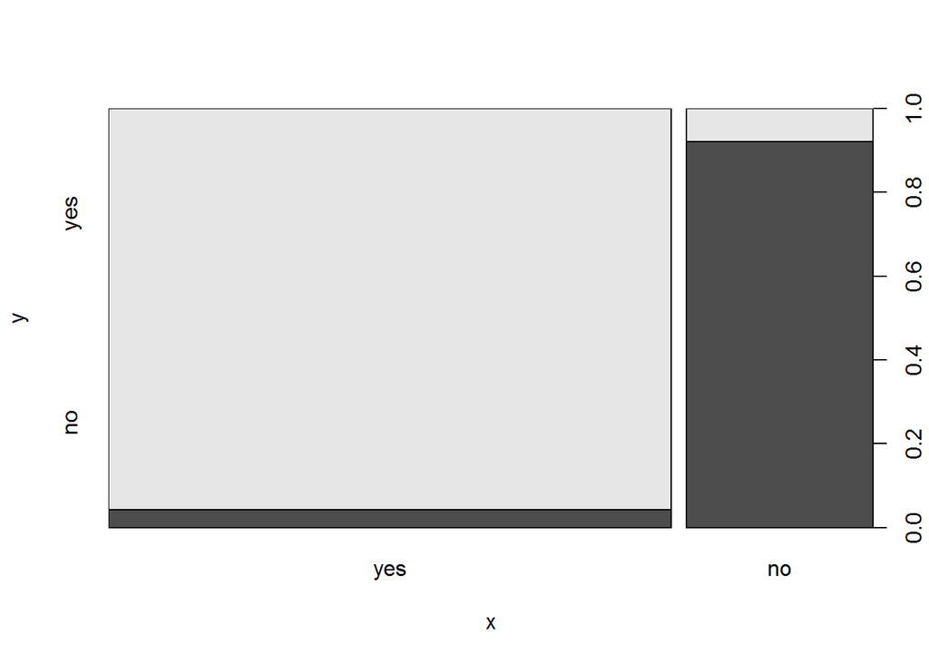

```r
# График "прогноз - реализация"
plot(yhat.bag, Boston$high.medv[-train])
```